# Week 3 Assessment - Data Visualization with ggplot2

Aminah Brown-Roopnarine

2026-09-27

# Exercise 1 — Reproducing and combining ggplot2 figures

## The Two figures

```r
nh <- read_csv("../Data /cleaned_NHANES.csv")
# Adjust the column names below to match the actual cleaned dataset
# (e.g., age, gender, ethnicity)
```

[output not shown]

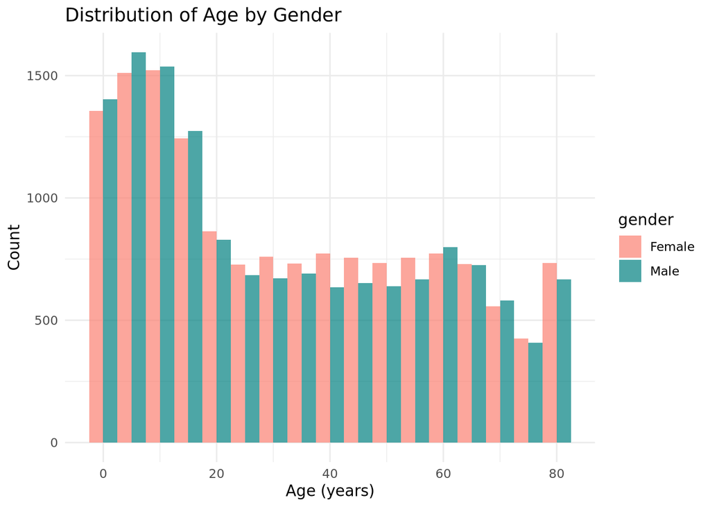

[output not shown]

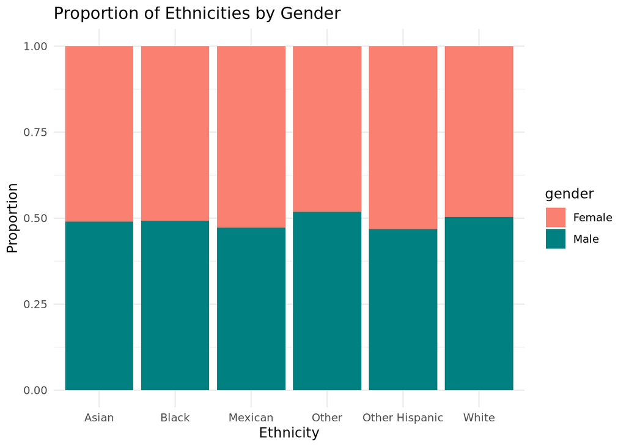

## Combined Plots

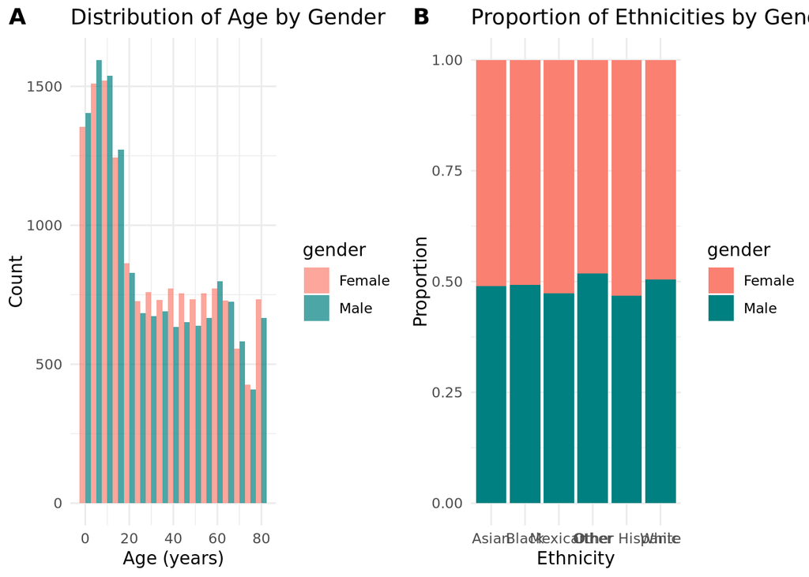

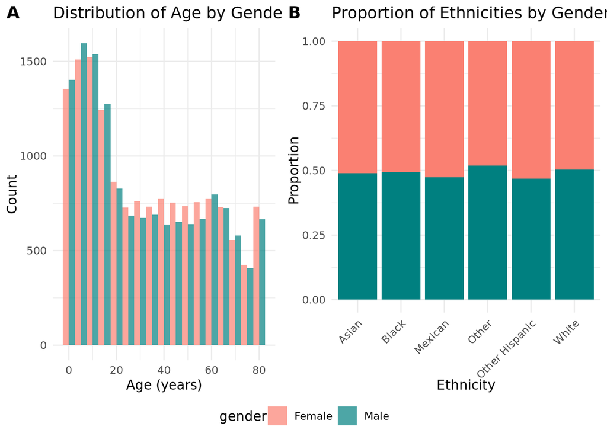

### Comparing `plot_grid()` and `ggarrange()`

`plot_grid()` (cowplot) is lightweight and gives fine control over axis alignment and the A/B labels. It is excellent when you want perfectly aligned panels.

`ggarrange()` (ggpubr) offers extra features: automatic legend alignment, shared axis labels, and richer layout options.

Based on the core uses of these respective functions, ggarrange() has a better layout for both of these plots.

For these two plots, `ggarrange()` generally produces a cleaner result because it aligns the two panels automatically and lets you share a common legend — reducing redundancy since both figures use the same gender colors. To elaborate, ggarrange() has “common. legend = TRUE”, which neatly gives you a single “gender” legend instead of two. plot_grid() doesn’t do this automatically. Additionally, it aligns the panels nicely, allowing for axis alignment to look polished while finalizing the figure.

# Exercise 2 — Visualizing key characteristics

## The four plots

```r
nh <- read_csv("../Data /cleaned_NHANES.csv")
# Adjust column names to match your actual cleaned dataset
```

### Age

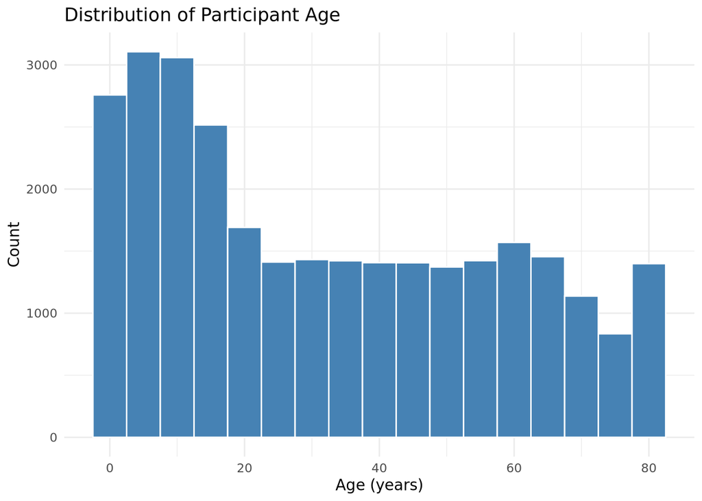

```r
p_age <- nh %>%
  ggplot(aes(x = age)) +
  geom_histogram(binwidth = 5, fill = "steelblue", color = "white") +
  labs(
    title = "Distribution of Participant Age",
    x = "Age (years)",
    y = "Count"
  ) +
  theme_minimal()

p_age
```

### Gender

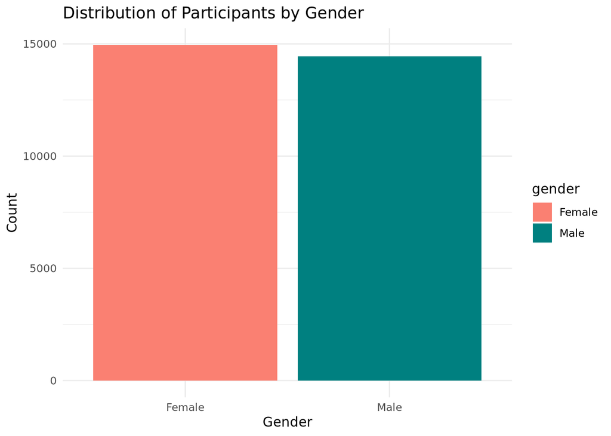

```r
p_gender <- nh %>%
  ggplot(aes(x = gender, fill = gender)) +
  geom_bar() +
  scale_fill_manual(values = c("#FA8072", "#008080")) +
  labs(
    title = "Distribution of Participants by Gender",
    x = "Gender",
    y = "Count"
  ) +
  theme_minimal()

p_gender
```

### First Ethnicity Variable

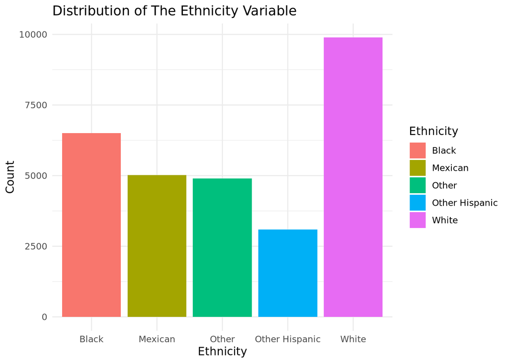

```r
p_eth1 <- nh %>%
  ggplot(aes(x = ethnicity_1 , fill = ethnicity_1)) +
  geom_bar() +
  labs(
    title = "Distribution of The Ethnicity Variable",
    x = "Ethnicity",
    y = "Count"
  ) +
  theme_minimal()
p_eth1 + scale_fill_discrete(name = "Ethnicity")
```

### Second Ethnicity Variable

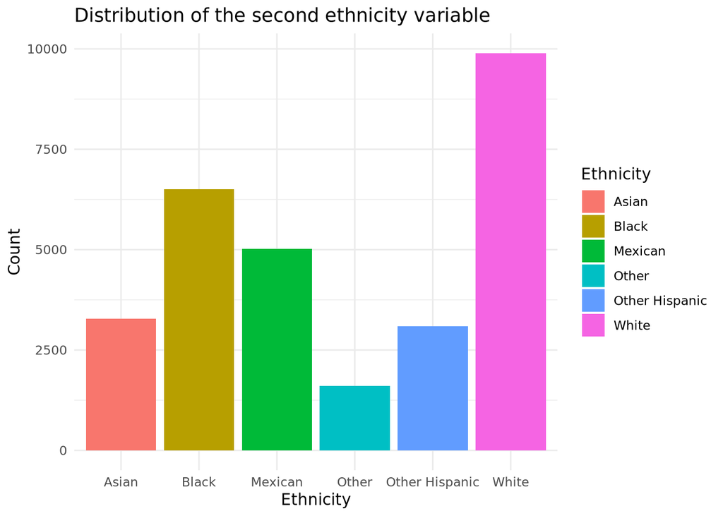

```r
p_eth2 <- nh %>%
  ggplot(aes(x = ethnicity_2, fill = ethnicity_2)) +
  geom_bar() +
  labs(
    title = "Distribution of the second ethnicity variable",
    x = "Ethnicity",
    y = "Count"
  ) +
  theme_minimal()
p_eth2 + scale_fill_discrete(name = "Ethnicity")
```

#### Missing values

```r
sum(is.na(nh$age))
```

```
## [1] 0
```

```r
sum(is.na(nh$gender))
```

```
## [1] 0
```

```r
sum(is.na(nh$ethnicity_1))
```

```
## [1] 0
```

```r
sum(is.na(nh$ethnicity_2))
```

```
## [1] 0
```

#### Describing the distributions

**Age:** roughly uniform across the adult range (the NHANES sample is designed to be representative), with missing values as reported above.

**Gender:** near-balanced split between males and females.

**Ethnicity:** uneven distribution, with some groups much more represented than others. Missing values as reported above.

#### Saving the plots

```r
ggsave("age_plot.png", p_age, width = 8, height = 5)
ggsave("gender_plot.png", p_gender, width = 8, height = 5)
ggsave("ethnicity_1_plot.png", p_eth1, width = 8, height = 5)
ggsave("ethnicity_2_plot.png", p_eth2, width = 8, height = 5)
```

#### Comparing the two ethnicity variables

```r
# Count how many categories each has
length(unique(nh$ethnicity_1))
```

```
## [1] 5
```

```r
length(unique(nh$ethnicity_2))
```

```
## [1] 6
```

```r
nh <- nh %>% select(-ethnicity_1)
```